# dbForge Data Compare

[**dbForge Data Compare**](https://www.devart.com/dbforge/mysql/datacompare/) helps compare and synchronize data in MariaDB, MySQL, and Percona databases and scripts folders. With this powerful GIU tool, you can easily find differences between your data, as it helps analyze comparison results, creates a synchronization script, and applies changes. Plus, MariaDB data can be compared with command-line support.

## dbForge Data Compare Tool Features:

### 1. Database Synchronization Features

- Create accurate synchronization scripts
- Synchronize asynchronous data
- Create custom scripts with execution before/after the process of data synchronization
- Get warning messages on errors during synchronization

[figure not shown]

### 2. MySQL & MariaDB Task Automation

- Automate routine synchronizations with a command-line interface
- Plan your routine execution with Windows Scheduler
- Support for PowerShell compatibility

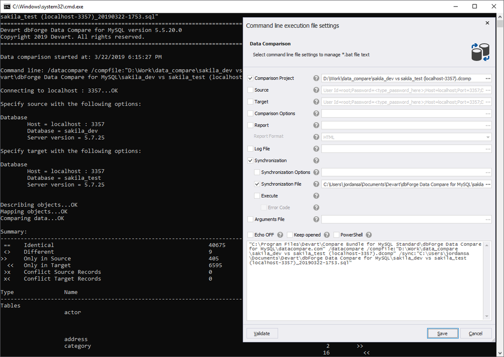

### 3. Script for Folder Data Comparison

- Compare data from your database with the data placed in the script folder locally
- Choose any database, connection, or script folder with the new Data Comparison Wizard
- See the data comparison results in a data result grid

[figure not shown]

### 4. Rich configurations for data comparison

- Enjoy various options for automatic mapping
- Compare customized queries
- Compare custom keys

[figure not shown]

### 5. Supported Data

- Tables
- Views
- BLOB data
- Compare databases and sync different MariaDB versions

### 6. Broad Compatibility Options

- All popular MariaDB server versions
- MariaDB set up on Windows, Linux, FreeBSD, etc.
- Various cloud services: Amazon RDS, Amazon Aurora, Google Cloud, Oracle MySQL Cloud, Alibaba Cloud
- Secure Socket Layer (SSL), Secure Shell (SSH), HTTP Tunneling, PAM Percona security connections

### 7. Manage Comparison Results

- Find tables by name
- Filter the comparison process results
- Enter the values of default comparison options
- Group records by type in each compared object

### 8. Export Comparison Results

- Use only relevant data in your reports
- Generate comparison reports in various formats

Download a free 30-day trial of dbForge Data Compare [here](https://www.devart.com/dbforge/mysql/datacompare/download.html).

[Documentation](https://docs.devart.com/data-compare-for-mysql)

| Version | Introduced |
| --- | --- |
| dbForge Data Compare 5.7 | Connectivity support for MariaDB 10.5 is added |
| dbForge Data Compare 5.5 | Support for MariaDB 10.4 |
| dbForge Data Compare 5.4 | Support for MariaDB 10.3 |
| dbForge Data Compare 5.3 | Support for MariaDB 10.2, Support for MariaDB 10.1 |
| dbForge Data Compare 4.1 | MariaDB 10.0, MariaDB 5.5 |

Content reproduced on this site is the property of its respective owners, and this content is not reviewed in advance by MariaDB. The views, information and opinions expressed by this content do not necessarily represent those of MariaDB or any other party.

© 2023 MariaDB  
Licensed under the Creative Commons Attribution 3.0 Unported License and the GNU Free Documentation License.  
https://mariadb.com/kb/en/dbforge-data-compare/